# Reporte de las comunas chilenas con mayor tasa de defunciones en el 2017

# Resumen

En Chile, gracias a los datos otorgados por el DEIS y el censo, es posible realizar un estudio, mediante uso de software estadístico, de las tasas de defunciones presentes en las comunas de Chile para el año 2017. El fin del análisis es encontrar patrones de comunas con alta tasa de mortalidad dentro de las regiones y así iniciar campañas de prevención donde sea necesario. Se realizó un estudio analítico de las defunciones en cada comuna, y así, se encontraron altas tasas de mortalidad en la Zona Sur del país con mayor énfasis en la región de la Araucanía, destacando enfermedades como la diabetes mellitus, enfermedades asociadas con el sistema circulatorio y enfermedad alcohólica del hígado, por lo que es necesario iniciar campañas de prevención en esos lugares.

# Introducción

Desde 1990 hasta la actualidad, en Chile existe un registro continuo, centralizado y obligatorio de las defunciones originadas en el país, por lo que la información de mortalidad se obtiene a través de estos datos. Podemos conocer abiertamente características como la frecuencia y la localización territorial. Particularmente en este informe, se hablará sobre la tasa de defunciones (o tasa de mortalidad) en las comunas del país que así lo ameriten y luego, un análisis específico buscando las enfermedades que conllevaron a una alta tasa de defunciones, todo esto en el contexto del año 2017.

Una alta tasa de mortalidad, quiere decir que en una zona están falleciendo más personas de lo habitual, por lo que este reporte se basará en el principio de que una zona que tenga una tasa alta necesita ser estudiada en profundidad para tomar medidas, porque por el contrario, estarán falleciendo personas por causas que pueden ser controladas por el estado. Si encontramos estas causas a tiempo, es posible iniciar estudios adicionales, y campañas preventivas para mejorar la condición de las comunas en cuestión.

En este informe se buscará a través de un análisis descriptivo con herramientas estadísticas, encontrar y conocer las comunas que requieran de este análisis, observando la tasa de defunciones que presenten.

En primer lugar, el reporte contendrá información sobre el panorama general del territorio nacional, especificando la tasa de mortalidad y población de cada región, para luego mostrar detalladamente dos mapas y una tabla de las regiones que contienen a las comunas con mayor tasa de defunciones. Posteriormente se realizará un análisis más específico de las comunas que presenten una tasa muy alta y se exhibirán dos tablas que contienen información más específica de las enfermedades que más provocan fallecimientos en la zona de estudio.

# Metodología

Para realizar este estudio se utilizó el software R a través de RStudio, donde se realizó un estudio descriptivo gracias a cruzar dos bases de datos. Una contiene información sobre defunciones otorgada por el Departamento de Estadísticas e información de Salud. La segunda base de datos, que contiene información sobre el Censo del año 2017, es otorgada por el package `chilemapas` de R.

La primera base mencionada en el párrafo anterior, que contiene variables continuas y discretas, tiene un total de 97 variables. Se realizó una limpieza de variables, entre los criterios que destacan, se encuentra eliminar variables numéricas que ya están siendo explicadas por variables categóricas, junto con eliminar variables que tengan 40% de datos faltantes o más, finalmente se obtuvo una base de datos con 87 variables. Entre las variables numéricas más destacadas podemos encontrar:

- Día de la fecha de nacimiento del fallecido.
- Mes de la fecha de nacimiento del fallecido.
- Año de la fecha de nacimiento del fallecido.
- Año de la fecha de inscripción de la defunción.
- Código del lugar ocurrencia de la defunción.
- Código de la región de residencia del fallecido.
- Región de residencia.
- Código del Servicio de Salud de residencia del fallecido.
- Código de la comuna de residencia del fallecido, de acuerdo a la división político-administrativa actualizada el 2019.
- Código para definir la zona Urbano o Rural de la residencia de la persona fallecida.

Por otro lado, algunas de las variables categóricas dentro de la base de datos son las siguientes.

- Causa básica de defunción en caso de muertes por enfermedades.
- Atención Médica.
- Estado nutritivo previo a la enfermedad cuando se trata de muerte de menor de un año.
- Fundamento de la causa de muerte.
- Describe el lugar donde ocurre la defunción.
- Enfermedad que conllevó a la defunción.
- Categoría a la que pertenece la enfermedad.

A continuación, se hablará de la segunda base de datos mencionada, esta contiene una menor cantidad de variables, porque solo contiene la siguiente información para las comunas de Chile:

- Código de la comuna.
- Código de la región.
- Rango de edad.
- Población.

Es necesario hacer hincapié en que la base de datos mencionada anteriormente solo tiene información sobre el Censo del año 2017, por lo que el análisis se redujo a ese año específicamente.

Al combinar estas bases de datos, se utilizaron estadísticos como la tasa de mortalidad, esta consiste en establecer una esperanza de muertes cada 100.000 habitantes de la zona en estudio. Se decidió que la tasa de mortalidad de una comuna es alta, cuando la tasa de mortalidad supera al tercer cuantil de la región a la que pertenece o cuando la tasa supera un valor de 800.

En el momento de hacer el análisis región a región se consideraron las regiones donde se vio una mayor tasa de mortalidad durante el estudio. Para cada región se exhibirá una visualización general, una visualización específica de las comunas de la región con mayor tasa de mortalidad, junto con una tabla con los mismos datos del punto anterior, adicionando información sobre la población.

Luego, para realizar el estudio comuna a comuna, se seleccionaron las que tengan una tasa de mortalidad mayor a 1000. Se consideró mostrar dos tablas para cada comuna, una que muestre información sobre las categorías de enfermedades que más provocaron defunciones, esto es, a que grupo de enfermedades pertenece cada enfermedad. Y posteriormente, una tabla que indique las enfermedades específicas que provocaron las mayores cantidades de defunciones en cada comuna. Ambas tablas contienen la cantidad de defunciones de cada categoría o enfermedad respectivamente en conjunto a la edad media.

# Información de defunciones a nivel nacional

Con el fin de analizar las defunciones en Chile desde una perspectiva completa hasta algo más detallado, primero estudiaremos a nivel nacional la tasa de mortalidad.

|  | Defunciones | Población | Tasa Mortalidad |
| --- | --- | --- | --- |
| Tarapacá | 1384 | 330558 | 419 |
| Antofagasta | 3104 | 607213 | 511 |
| Atacama | 1548 | 286168 | 541 |
| Coquimbo | 4397 | 757586 | 580 |
| Valparaíso | 12582 | 1815902 | 693 |
| Libertador General Bernardo O'higgins | 5440 | 914555 | 595 |
| Maule | 6663 | 1044950 | 638 |
| Biobío | 9833 | 1556805 | 632 |
| La Araucanía | 6652 | 957224 | 695 |
| Los Lagos | 5426 | 828708 | 655 |

[output cut: 7 more lines]

Tabla 1: Tasa de Mortalidad por Región

Tal como se logra apreciar en la Tabla 1, la región de Los Ríos es la que presentó mayor tasa de mortalidad en el año de estudio. En cambio, la menor tasa de mortalidad la presenta la región de Tarapacá.

# Información de defunciones según región

Se consideraron cinco regiones donde se pueden apreciar comunas con tasa de defunción alta, para comenzar se presentará a la región del Maule.

## Región del Maule

A continuación, se enseñará un mapa con la tasa de mortalidad a nivel regional.

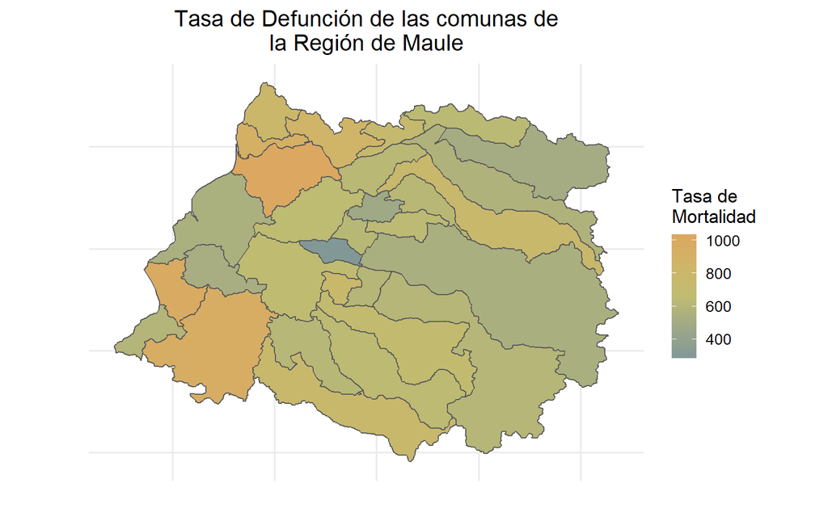

En esta región, las tasas de defunción son altas, y se destacan principalmente las comunas costeras.

El siguiente mapa destaca las comunas que tienen una mayor tasa de mortalidad en la región.

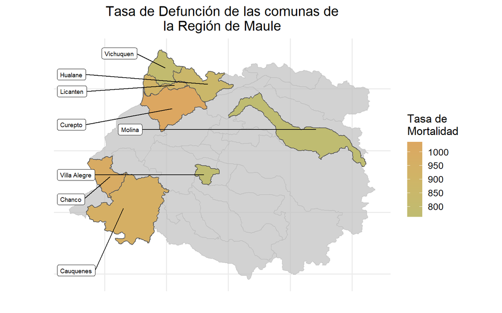

A partir del mapa anterior es posible evidenciar dos grupos, ubicados en la zona oeste del mapa, en particular destaca la comuna de Curepto.

La siguiente tabla muestra las comunas que aparecen en el gráfico anterior con más detalle, incluyendo defunciones, población y tasa de mortalidad.

|  | Defunciones | Población | Tasa Mortalidad |
| --- | --- | --- | --- |
| Curepto | 98 | 9448 | 1037 |
| Chanco | 89 | 8928 | 997 |
| Cauquenes | 387 | 40441 | 957 |
| Licanten | 61 | 6653 | 917 |
| Hualane | 83 | 9657 | 859 |
| Vichuquen | 34 | 4322 | 787 |
| Villa Alegre | 124 | 16221 | 764 |
| Molina | 351 | 45976 | 763 |

Tabla 2: Tasa de Mortalidad en las comunas destacadas de la región

Como se observa en la Tabla 2, hay cinco comunas de esta región que presentan una tasa de mortalidad considerable (mayor a 800), por lo que encuentro necesario prestar atención a esta región para tomar las medidas necesarias.

## Región de la Araucanía

En el caso de la región de la Araucanía también se aprecia una alta tasa de mortalidad en algunas comunas. El siguiente mapa muestra la visión global en esta región

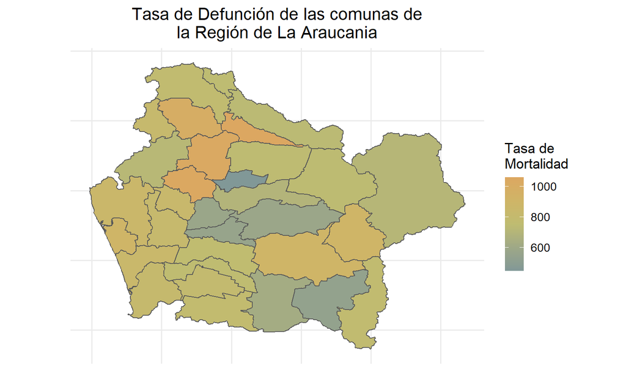

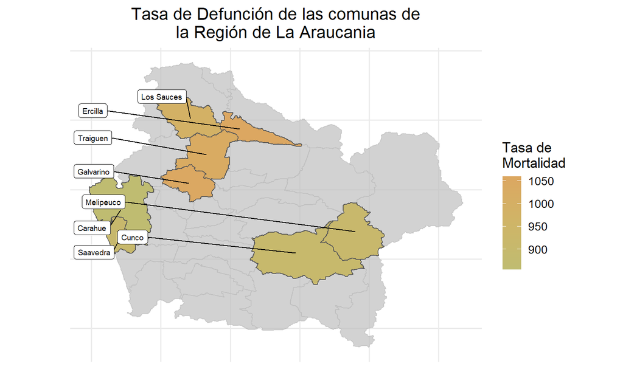

En este mapa se destacan a tres comunas aledañas: Traiguen, Galvarino y Ercilla, que presentan una tasa de mortalidad bastante alta. En la siguiente tabla se encuentra el detalle de la tasa de mortalidad por comuna en la región.

|  | Defunciones | Población | Tasa Mortalidad |
| --- | --- | --- | --- |
| Ercilla | 82 | 7733 | 1060 |
| Galvarino | 126 | 11996 | 1050 |
| Traiguen | 195 | 18843 | 1035 |
| Los Sauces | 72 | 7265 | 991 |
| Melipeuco | 56 | 6138 | 912 |
| Saavedra | 113 | 12450 | 908 |
| Cunco | 159 | 17526 | 907 |
| Carahue | 210 | 24533 | 856 |

Tabla 3: Tasa de Mortalidad en las comunas destacadas de la región

Como se observa, la tasa de mortalidad de las regiones anteriormente mencionadas es muy alta y se encuentra por sobre la media nacional.

## Región de los Lagos

Como veremos en el siguiente mapa de la región, Los Lagos también presenta una tasa de defunción alta.

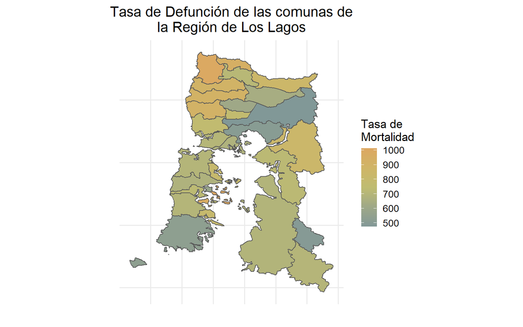

La zona norte es la que presenta mayor tasa de mortalidad. En general, se puede ver que la tasa de defunciones es bastante variada. En el mapa de a continuación, se podrá apreciar una visualización de las comunas con mayor tasa de mortalidad en la región.

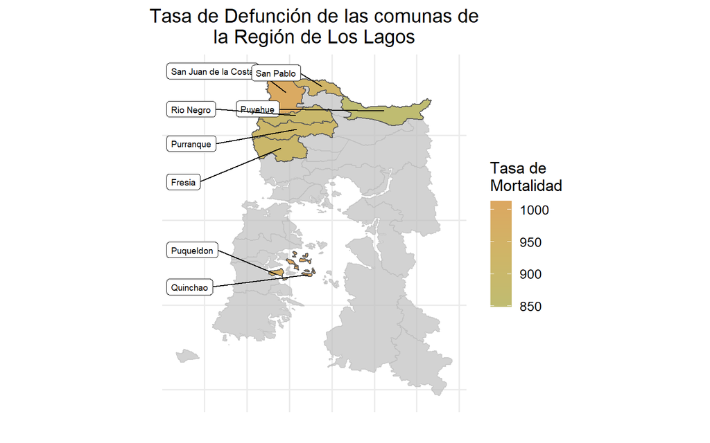

Gracias a este mapa, podemos ver que las comunas de San Juan de la Costa, Puqueldon y Quinchao tienen una tasa de mortalidad muy elevada. En la siguiente tabla se puede apreciar con mayor detalle las comunas con tasa de defunción alta.

|  | Defunciones | Población | Tasa Mortalidad |
| --- | --- | --- | --- |
| Quinchao | 82 | 8088 | 1014 |
| San Juan de la Costa | 75 | 7512 | 998 |
| Puqueldon | 38 | 3921 | 969 |
| San Pablo | 94 | 10030 | 937 |
| Purranque | 186 | 20369 | 913 |
| Fresia | 111 | 12261 | 905 |
| Rio Negro | 127 | 14085 | 902 |
| Puyehue | 99 | 11667 | 849 |

Tabla 4: Tasa de Mortalidad en las comunas destacadas de la región

Es posible apreciar en la Tabla 4 que las tasas de mortalidad son muy altas en estas comunas, se puede hacer especial énfasis a Quinchao, que tiene una tasa de mortalidad sobre 1000 personas por cada 100000 habitantes.

## Región Metropolitana

A continuación se mostrará el mapa de la Región Metropolitana (RM) para apreciar generalmente la tasa de defunción de cada comuna, en este caso se omitieron algunas comunas periféricas para que se visualice mejor la ciudad de Santiago.

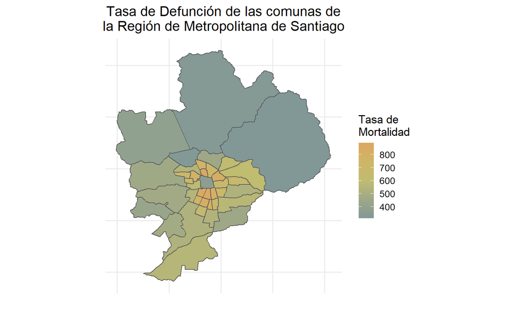

Se puede apreciar que las comunas con mayor tasa de mortalidad pertenecen a la zona céntrica de la RM, sin embargo la comuna más central (Santiago Centro), presenta una tasa de mortalidad más baja en comparación a las comunas aledañas. La gráfica de a continuación resalta solo las comunas con tasa de defunción alta.

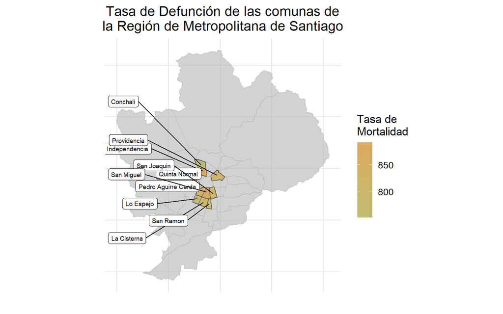

En este mapa se logra evidenciar que todas las comunas resaltadas, excepto Providencia, pertenecen a estratos sociales medios-bajos. El lector puede ver más detalles sobre estas comunas en la siguiente tabla.

|  | Defunciones | Población | Tasa Mortalidad |
| --- | --- | --- | --- |
| Independencia | 895 | 100281 | 892 |
| San Miguel | 938 | 107954 | 869 |
| Pedro Aguirre Cerda | 860 | 101174 | 850 |
| La Cisterna | 735 | 90119 | 816 |
| Providencia | 1160 | 142079 | 816 |
| San Joaquin | 770 | 94492 | 815 |
| San Ramon | 652 | 82900 | 786 |
| Quinta Normal | 860 | 110026 | 782 |
| Conchali | 960 | 126955 | 756 |
| Lo Espejo | 744 | 98804 | 753 |

Tabla 5: Tasa de Mortalidad en las comunas destacadas de la región

La tabla anterior nos permite observar que, si bien las tasas de mortalidad de la región son altas, no lo son tanto como en las regiones anteriormente señaladas.

## Región del Ñuble

La siguiente visualización permite hacer dar cuenta de las tasas de defunción en la región del Ñuble.

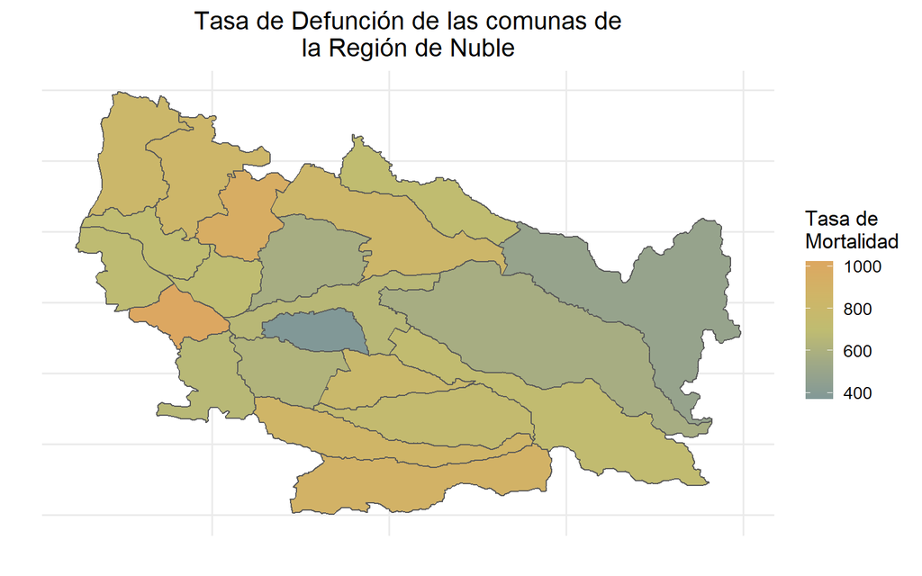

Esta visualización nos informa que hay una tasa de mortalidad bastante variada a lo largo de la región de estudio, además aparentemente no es posible señalar una tendencia. Hay una comuna que destaca en particular que está en la zona costera de la región, y que tiene una tasa de mortalidad sobresaliente comparada al resto. A continuación, se exhibe un mapa donde se puede observar a las comunas con mayor tasa de mortalidad.

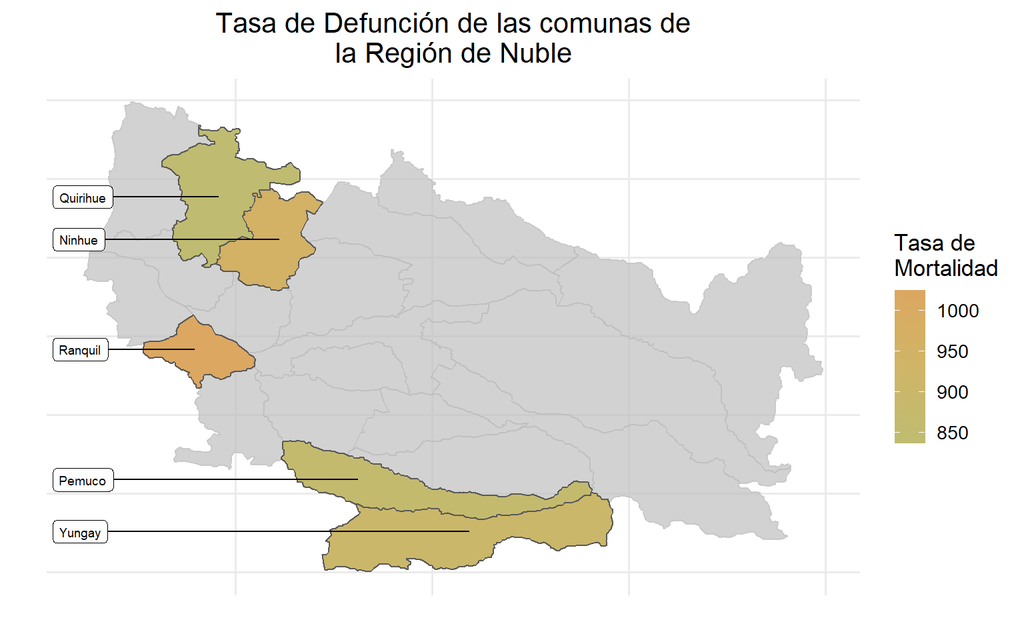

Podemos ver como destaca Ranquil por sobre el resto en este mapa. Sin embargo, vemos que zonas ubicadas en el sector occidente de la región tienen una tasa de mortalidad alta. En la siguiente tabla se muestran más detalles sobre estas comunas.

|  | Defunciones | Población | Tasa Mortalidad |
| --- | --- | --- | --- |
| Ranquil | 59 | 5755 | 1025 |
| Ninhue | 50 | 5213 | 959 |
| Yungay | 160 | 17787 | 900 |
| Pemuco | 73 | 8448 | 864 |
| Quirihue | 97 | 11594 | 837 |

Tabla 6: Tasa de Mortalidad en las comunas destacadas de la región

La Tabla 6 nos permite observar que hay tres comunas con tasa de mortalidad muy elevada, podemos ver que hay diferencias a nivel de población en cada comuna.

# Causas de defunciones en las comunas con alta tasa de mortalidad

Se estudió con mayor detalle las comunas de territorio nacional con mayor tasa de mortalidad. Para ello, se utilizó la siguiente tabla.

|  | Defunciones | Población | Tasa Mortalidad |
| --- | --- | --- | --- |
| Ercilla | 82 | 7733 | 1060 |
| Galvarino | 126 | 11996 | 1050 |
| Curepto | 98 | 9448 | 1037 |
| Traiguen | 195 | 18843 | 1035 |
| Ranquil | 59 | 5755 | 1025 |
| Quinchao | 82 | 8088 | 1014 |
| San Juan de la Costa | 75 | 7512 | 998 |
| Chanco | 89 | 8928 | 997 |
| Los Sauces | 72 | 7265 | 991 |
| Puqueldon | 38 | 3921 | 969 |

Tabla 7: Comunas con mayor tasa de defunciones a nivel país

En la Tabla 7 se hace evidente que hay seis comunas a nivel nacional con una tasa de mortalidad por sobre 1000. Debido a esta alta tasa de mortalidad, se decidió hacer un análisis en profundidad sobre ellas.

## Quinchao

La siguiente tabla muestra la cantidad de defunciones y la edad media de las personas que fallecieron según el tipo de enfermedad en Quinchao.

| Causa | Defunciones | Edad Media |
| --- | --- | --- |
| Enfermedades del sistema circulatorio | 21 | 80 |
| Tumores [Neoplasias] | 13 | 66 |
| Enfermedades del sistema digestivo | 12 | 60 |
| Enfermedades del sistema respiratorio | 10 | 84 |
| Traumatismos, envenenamientos y algunas otras consecuencias de causas externas | 8 | 52 |

Tabla 8: Tipos de enfermedades que conllevaron a defunciones en la comuna

Las enfermedades relacionadas con el sistema circulatorio fueron notoriamente las mayores causantes de defunciones en Quinchao. Además, se encontró que hay tres categorías causantes de defunciones que tuvieron media de 66 años o menos. En la tabla que se aprecia a continuación se muestra las principales enfermedades que desembocaron en una defunción en la comuna.

| Causa | Defunciones | Edad Media |
| --- | --- | --- |
| Enfermedad alcohólica del hígado | 6 | 53 |
| Otras enfermedades pulmonares obstructivas crónicas | 4 | 91 |
| Accidente vascular encefálico agudo, no especificado como hemorrágico o isquémico | 3 | 89 |
| Diabetes mellitus no insulinodependiente | 3 | 77 |
| Hipertensión esencial (primaria) | 3 | 89 |
| Infarto agudo del miocardio | 3 | 70 |
| Úlcera de de cúbito | 3 | 88 |
| Efectos de otras causas externas | 2 | 51 |
| Enfermedad (Insuficiencia) renal crónica | 2 | 79 |
| Enfermedad cardíaca hipertensiva | 2 | 83 |

Tabla 9: Enfermedades que conllevaron a defunciones en la comuna

## Ranquil

Siguiendo con el análisis de cada comuna, veamos una tabla con las categorías de para el caso de Ranquil, una de las zonas con mayor tasa de defunción.

| Causa | Defunciones | Edad Media |
| --- | --- | --- |
| Tumores [Neoplasias] | 18 | 75 |
| Enfermedades del sistema circulatorio | 11 | 77 |
| Enfermedades del sistema digestivo | 7 | 70 |
| Enfermedades del sistema respiratorio | 5 | 81 |
| Enfermedades endocrinas, nutricionales y metabólicas | 5 | 80 |

Tabla 10: Tipos de enfermedades que conllevaron a defunciones en la comuna

| Causa | Defunciones | Edad Media |
| --- | --- | --- |
| Diabetes mellitus no insulinodependiente | 4 | 82 |
| Enfermedad alcohólica del hígado | 4 | 62 |
| Secuelas de enfermedad cerebrovascular | 3 | 87 |
| Traumatismos múltiples, no especificados | 3 | 65 |
| Tumor maligno de la vejiga urinaria | 3 | 71 |
| Tumor maligno del estómago | 3 | 81 |
| Embolia pulmonar | 2 | 62 |
| Enfermedad de Parkinson | 2 | 85 |
| Infarto agudo del miocardio | 2 | 71 |
| Neumonía, organismo no especificado | 2 | 82 |

Tabla 11: Enfermedades que conllevaron a defunciones en la comuna

Podemos ver en la Tabla 11 que las mayores cantidades de defunciones las tienen la diabetes mellitus y la enfermedad alcohólica del hígado.

## Traiguen

Continuando el estudio, la siguiente tabla señala información sobre las categorías de las enfermedades que causaron defunciones en la comuna de Traiguen.

| Causa | Defunciones | Edad Media |
| --- | --- | --- |
| Enfermedades del sistema circulatorio | 46 | 81 |
| Enfermedades del sistema respiratorio | 29 | 82 |
| Tumores [Neoplasias] | 29 | 76 |
| Traumatismos, envenenamientos y algunas otras consecuencias de causas externas | 19 | 49 |
| Síntomas, signos y hallazgos anormales clínicos y de laboratorio, no clasificados en otra parte | 17 | 76 |

Tabla 12: Tipos de enfermedades que conllevaron a defunciones en la comuna

Gracias a la tabla anterior es posible concluir que las defunciones asociadas a enfermedades del sistema circulatorio a predominan ampliamente, seguidas luego por las enfermedades del sistema respiratorio. Las defunciones por causas externas cobraron la vida de personas que en promedio tenían 49 años, una edad muy temprana. Podemos ver con aún más detalle las enfermedades específicas que causaron defunciones en la comuna en la siguiente tabla.

| Causa | Defunciones | Edad Media |
| --- | --- | --- |
| Otras causas mal definidas y las no especificadas de mortalidad | 17 | 76 |
| Neumonía, organismo no especificado | 12 | 85 |
| Secuelas de enfermedad cerebrovascular | 9 | 85 |
| Enfermedad cardíaca hipertensiva | 8 | 74 |
| Hipertensión esencial (primaria) | 8 | 86 |
| Tumor maligno del estómago | 7 | 77 |
| Enfermedad alcohólica del hígado | 5 | 50 |
| Otras enfermedades del hígado | 5 | 64 |
| Otras enfermedades pulmonares obstructivas crónicas | 5 | 81 |
| Asfixia | 4 | 46 |

Tabla 13: Enfermedades que conllevaron a defunciones en la comuna

Sin considerar las defunciones no especificadas, en la Tabla 13 podemos ver que las defunciones por neumonía en esta comuna son un gran número, podemos destacar nuevamente la presencia de defunciones por enfermedad alcohólica del hígado.

## Curepto

Continuando el estudio, se enseñarán las categorías de enfermedades que más causaron defunciones en Curepto, junto a la cantidad de estas y la edad media respectiva. Para ello veamos la siguiente tabla.

| Causa | Defunciones | Edad Media |
| --- | --- | --- |
| Enfermedades del sistema circulatorio | 25 | 81 |
| Tumores [Neoplasias] | 23 | 70 |
| Enfermedades del sistema respiratorio | 12 | 80 |
| Enfermedades endocrinas, nutricionales y metabólicas | 10 | 88 |
| Enfermedades del sistema digestivo | 7 | 76 |

Tabla 14: Tipos de enfermedades que conllevaron a defunciones en la comuna

A partir de la tabla anterior, es posible concluir que enfermedades del sistema circulatorio son las mayores causantes de defunciones en la comuna de Curepto. También existe una cantidad parecida de defunciones por Tumores, que cobraron la vida de personas que en promedio tenían 70 años. La tabla posterior indica con mayor especificidad las enfermedades que más llevaron a defunciones en la comuna.

| Causa | Defunciones | Edad Media |
| --- | --- | --- |
| Neumonía, organismo no especificado | 5 | 81 |
| Diabetes mellitus, no especificada | 4 | 90 |
| Hipertensión esencial (primaria) | 4 | 81 |
| Infarto agudo del miocardio | 4 | 87 |
| Tumor maligno de la vesícula biliar | 4 | 71 |
| Linfoma no Hodgkin de otro tipo y el no especificado | 3 | 68 |
| Neumonía bacteriana, no clasificada en otra parte | 3 | 85 |
| Otras enfermedades del hígado | 3 | 73 |
| Accidente vascular encefálico agudo, no especificado como hemorrágico o isquémico | 2 | 72 |
| Diabetes mellitus no insulinodependiente | 2 | 88 |

Tabla 15: Enfermedades que conllevaron a defunciones en la comuna

Se destacan en la Tabla 15 las defunciones producidas por Neumonía, al igual que la diabetes mellitus. En general las cantidades de defunciones son bajas, pero considerables, ya que es una comuna con pocos habitantes. (Ver tabla del comienzo de esta sección)

## Galvarino

Esta comuna, ubicada en la región de la Araucanía, presenta los siguientes tipos de enfermedades que terminaron en defunciones.

| Causa | Defunciones | Edad Media |
| --- | --- | --- |
| Enfermedades del sistema circulatorio | 25 | 80 |
| Tumores [Neoplasias] | 20 | 70 |
| Síntomas, signos y hallazgos anormales clínicos y de laboratorio, no clasificados en otra parte | 19 | 83 |
| Enfermedades del sistema respiratorio | 15 | 84 |
| Traumatismos, envenenamientos y algunas otras consecuencias de causas externas | 14 | 40 |

Tabla 16: Tipos de enfermedades que conllevaron a defunciones en la comuna

Podemos ver en la Tabla 16 que destacan los fallecimientos gracias a enfermedades del sistema circulatorio, seguidos por cifras altas de defunciones por Tumores y hallazgos anormales. Es posible ver en la tabla de a continuación, las enfermedades específicas que produjeron la mayor cantidad de muertes en la comuna de Galvarino.

| Causa | Defunciones | Edad Media |
| --- | --- | --- |
| Otras causas mal definidas y las no especificadas de mortalidad | 18 | 83 |
| Diabetes mellitus, no especificada | 6 | 68 |
| Hemorragia intraencefálica | 5 | 77 |
| Otras enfermedades pulmonares intersticiales | 5 | 76 |
| Enfermedad (Insuficiencia) renal crónica | 4 | 86 |
| Enfermedad alcohólica del hígado | 4 | 66 |
| Hipertensión esencial (primaria) | 4 | 79 |
| Otras enfermedades pulmonares obstructivas crónicas | 4 | 88 |
| Traumatismo intracraneal | 4 | 28 |
| Tumor maligno de la vesícula biliar | 4 | 65 |

Tabla 17: Enfermedades que conllevaron a defunciones en la comuna

En esta tabla, las causas no definidas son las mayores causantes de defunciones, no se pudo contar en el análisis con más información sobre estas defunciones. Con un número tres veces menor, predominan las defunciones por diabetes mellitus.

## Ercilla

Esta es una comuna que se encuentra en la Región de la Araucanía y fue la última comuna a la que se le realizó un análisis más profundo. La siguiente tabla habla de las categorías de enfermedades que conllevaron a defunciones.

| Causa | Defunciones | Edad Media |
| --- | --- | --- |
| Enfermedades del sistema circulatorio | 20 | 82 |
| Tumores [Neoplasias] | 15 | 74 |
| Traumatismos, envenenamientos y algunas otras consecuencias de causas externas | 10 | 43 |
| Enfermedades del sistema digestivo | 8 | 68 |
| Enfermedades del sistema respiratorio | 7 | 73 |

Tabla 18: Tipos de enfermedades que conllevaron a defunciones en la comuna

En la Tabla 18, las categorías predominantes son las enfermedades del sistema circulatorio y tumores, con una edad media de 82 y 74 años respectivamente. En la Tabla 19 se podrá ver más exactamente cuáles son las enfermedades que más defunciones producen defunciones en la comuna de Ercilla.

| Causa | Defunciones | Edad Media |
| --- | --- | --- |
| Diabetes mellitus no insulinodependiente | 4 | 70 |
| Enfermedad cardíaca hipertensiva | 4 | 83 |
| Infarto agudo del miocardio | 4 | 73 |
| Neumonía, organismo no especificado | 4 | 85 |
| Traumatismo intracraneal | 4 | 46 |
| Enfermedad (Insuficiencia) renal crónica | 3 | 90 |
| Otras enfermedades del hígado | 3 | 57 |
| Tumor maligno de la próstata | 3 | 82 |
| Accidente vascular encefálico agudo, no especificado como hemorrágico o isquémico | 2 | 93 |
| Diabetes mellitus, no especificada | 2 | 56 |

Tabla 19: Enfermedades que conllevaron a defunciones en la comuna

Dada la información en la tabla anterior, se puede observar que las defunciones son bajas, aun así sobresalen los fallecimientos por diabetes mellitus. Además, destacan dos enfermedades relacionadas con el sistema circulatorio, como lo son la enfermedad cardiaca hipertensiva y el infarto agudo al miocardio.

# Conclusiones

Una vez exhibidos los resultados obtenidos durante la investigación, podemos obtener la conclusión de que, dentro del territorio nacional, las regiones más australes son las que tienen mayores tasas de mortalidad, por lo que en mi opinión, deberían enfocarse recursos a la Zona Sur de Chile.

La existencia de patrones, por ejemplo, que hayan más defunciones en la zona costera que en la cordillerana, es muy importante de investigar con el fin de enfocar los recursos a estas zonas. Es necesario señalar que la existencia de patrones dentro de cada región, también es necesario estudiarla con más detalle.

A través de una vista panorámica de las causantes de defunciones, podemos ver desde la Tabla 8 en adelante, que las enfermedades predominantes son las relacionadas con el sistema circulatorio. Es importante incrementar las campañas de prevención para prevenir estas enfermedades que afectan a la población que pertenece al grupo etario de entre los 50 y 70 años (“Infarto al miocardio”. Hospitales Angeles, s. f.).

Hablando específicamente de las enfermedades, una de las que más sobresalió fue la enfermedad hepática al hígado. En general, Chile es un país que presenta altos índices de consumo de alcohol, que han ido presentando incrementos en los últimos años. (“Aumento del consumo de alcohol, el otro efecto de la pandemia”. Universidad San Sebastian, (s. f.)). La otra enfermedad que destacó también fue la diabetes mellitus, si bien el factor genético es inalterable, hay estudios que señalan que malos hábitos alimentarios incrementan el riesgo de desarrollar diabetes, en especial en estudiantes universitarios. (Fernandez M. & López M., 2019). En mi opinión, iniciar campañas preventivas que generen difusión y concientización es muy importante con el fin de disminuir la cantidad de fallecimientos que presentan ambas enfermedades.

Finalmente, encuentro que existe la necesidad de realizar un análisis con más profundidad, que otorgue más información sobre las características sociales de las personas que habitan en comunas con tasa de mortalidad alta, porque Chile es un país desarrollado, y por esto, contará con grandes números de defunciones sobre las enfermedades señaladas durante el informe.

# Referencias bibliográficas

1. Infarto de miocardio (s. f.). Hospitales Angeles. Recuperado de: https://hospitalesangeles.com/saludyvida/padecimientos/articulo.php?id=1149#:~:text=La%20edad%20promedio%20de%20mayor,los%20factores%20de%20riesgo%20que.
2. Aumento del consumo de alcohol, el otro efecto de la pandemia (s. f.). Universidad San Sebastian. Recuperado de: https://www.uss.cl/blog/aumento-consumo-alcohol-pandemia/.
3. Fernandez M. & López M. (2019) Relación entre hábitos alimentarios y riesgo de desarrollar diabetes en universitarios mexicanos. Nutrición Clínica y Dietética Hospitalaria. 39(4): 32-40.